# Plant Seedlings Image Classification

### Background

Provided is the dataset of images of plant seedlings at various stages of growth. Each image has a filename that is its unique id. The dataset comprises 12 plant species. The goal is to create a classifier capable of determining a plant's species from a photo.

##### Objective:

The ability to differentiate a weed from a crop seedling effectively for better crop yields and better stewardship of the environment.

### Data Context

Dataset contains images of unique plants belonging to 12 species at several growth stages The data file names are:

1. images.npy
2. Label.csv

#### Importing all the required packages for the project:

```python
#Reading the training images from the path and labelling them into the given categories
import numpy as np
import pandas as pd
import matplotlib.pyplot as plt
import cv2
import os        # This module provides a portable way of using operating system dependent functionality.
import seaborn as sns # for data visualization
import tensorflow as tf
import keras
from keras.preprocessing.image import ImageDataGenerator
from sklearn import preprocessing
from tensorflow.keras.models import Sequential #sequential api for sequential model
from tensorflow.keras.layers import Dense, Dropout, Flatten #importing different layers
from tensorflow.keras.layers import Conv2D, MaxPooling2D, BatchNormalization, Activation, Input, LeakyReLU,Activation
from tensorflow.keras import backend as K
from tensorflow.keras.utils import to_categorical #to perform one-hot encoding
from keras.layers import Dense, Dropout, Flatten, Conv2D, MaxPool2D
from tensorflow.keras.optimizers import RMSprop,Adam
#from keras.optimizers import RMSprop,Adam #optimiers for optimizing the model
from keras.callbacks import EarlyStopping  #regularization method to prevent the overfitting
from keras.callbacks import ModelCheckpoint
from tensorflow.keras.models import Sequential, Model
from tensorflow.keras import losses, optimizers
from sklearn.model_selection import train_test_split
from sklearn.metrics import classification_report, confusion_matrix
```

```python
plant_names = pd.read_csv(r"C:\Users\user\Desktop\AI_ML_Austin\notebook prog files\ProjectWork8\Labels.csv")
```

```python
plant_names.head(10)
```

|  | Label |
| --- | --- |
| 0 | Small-flowered Cranesbill |
| 1 | Small-flowered Cranesbill |
| 2 | Small-flowered Cranesbill |
| 3 | Small-flowered Cranesbill |
| 4 | Small-flowered Cranesbill |
| 5 | Small-flowered Cranesbill |
| 6 | Small-flowered Cranesbill |
| 7 | Small-flowered Cranesbill |
| 8 | Small-flowered Cranesbill |
| 9 | Small-flowered Cranesbill |

```python
plant_names.dtypes.value_counts()
```

```
object    1
dtype: int64
```

```python
plant_names.info()
```

```
<class 'pandas.core.frame.DataFrame'>
RangeIndex: 4750 entries, 0 to 4749
Data columns (total 1 columns):
 #   Column  Non-Null Count  Dtype
---  ------  --------------  -----
 0   Label   4750 non-null   object
dtypes: object(1)
memory usage: 37.2+ KB
```

```python
plant_names.describe(
    include="all"
).T  #describe all dataset. Use transpose so column wise details can be view from top to bottom
```

|  | count | unique | top | freq |
| --- | --- | --- | --- | --- |
| Label | 4750 | 12 | Loose Silky-bent | 654 |

```python
#Distinct values
plant_names['Label'].nunique()
```

```
12
```

```python
(plant_names.Label.value_counts())/(plant_names.Label.count())
```

```
Loose Silky-bent             0.137684
Common Chickweed             0.128632
Scentless Mayweed            0.108632
Small-flowered Cranesbill    0.104421
Fat Hen                      0.100000
Charlock                     0.082105
Sugar beet                   0.081053
Cleavers                     0.060421
Black-grass                  0.055368
Shepherds Purse              0.048632
Maize                        0.046526
Common wheat                 0.046526
Name: Label, dtype: float64
```

### EDA

```python
# function to label barplot
def labeled_barplot(data, feature, perc=False, n=None):
    total = len(data[feature])  # length of the column
    count = data[feature].nunique()
    if n is None:
        plt.figure(figsize=(count + 1, 5))
    else:
        plt.figure(figsize=(n + 1, 5))

    plt.xticks(rotation=90, fontsize=15)
    ax = sns.countplot(
        data=data,
        x=feature,
        palette="Paired",
        order=data[feature].value_counts().index[:n].sort_values(),
    )

    for p in ax.patches:
        if perc == True:
            label = "{:.1f}%".format(
                100 * p.get_height() / total
            )  # percentage of each class of the category
        else:
            label = p.get_height()  # count of each level of the category

        x = p.get_x() + p.get_width() / total  # width of the plot
        y = p.get_y() + p.get_height() + 1.5  # height of the plot

        ax.annotate(label, (x, y), size=12, rotation=0)  # annotate the percentage

    plt.show()  # show the plot
```

### Data Analysis: Univariate Analysis

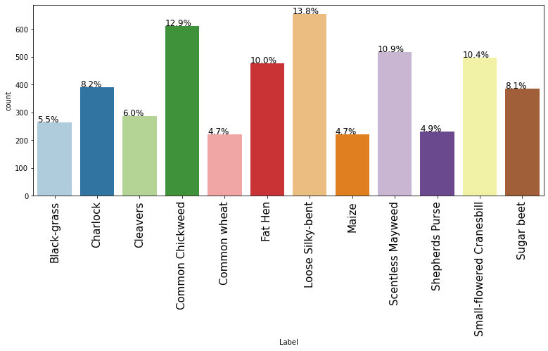

```python
labeled_barplot(plant_names, "Label", perc=True)  # barplot
```

```python
img_array = np.load(r"C:\Users\user\Desktop\AI_ML_Austin\notebook prog files\ProjectWork8\images.npy")
```

```python
Img = np.asarray(img_array) # Train images set
print(Img.shape)
```

```
(4750, 128, 128, 3)
```

```python
trainingImg = np.asarray(Img)
trainLabel = pd.DataFrame(plant_names)
```

```python
trainImg.shape, trainLabel.shape
```

```
((4750, 128, 128, 3), (4750, 1))
```

```
Image name:Black-grass
```

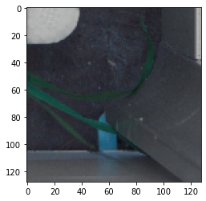

```python
i = 3835
img1 = trainImg[i]
label = trainLabel['Label'].values[i]
print(f'Image name:{label}')
plt.imshow(img1)
```

```
Image name:Charlock
```

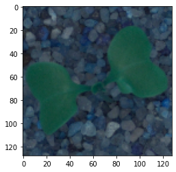

```python
i = 2036
img1 = trainImg[i]
label = trainLabel['Label'].values[i]
print(f'Image name:{label}')
plt.imshow(img1)
```

```
Image name:Cleavers
```

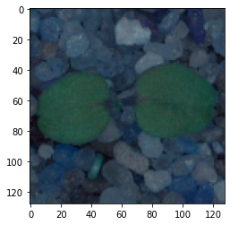

```python
i = 2426
img1 = trainImg[i]
label = trainLabel['Label'].values[i]
print(f'Image name:{label}')
plt.imshow(img1)
```

```
Image name:Common Chickweed
```

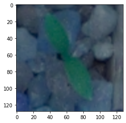

```python
i = 1425
img1 = trainImg[i]
label = trainLabel['Label'].values[i]
print(f'Image name:{label}')
plt.imshow(img1)
```

```
Image name:Common wheat
```

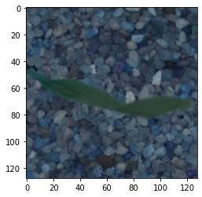

```python
i = 1230
img1 = trainImg[i]
label = trainLabel['Label'].values[i]
print(f'Image name:{label}')
plt.imshow(img1)
```

```
Image name:Fat Hen
```

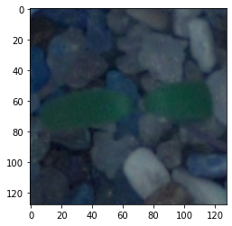

```python
i = 498
img1 = trainImg[i]
label = trainLabel['Label'].values[i]
print(f'Image name:{label}')
plt.imshow(img1)
```

```
Image name:Loose Silky-bent
```

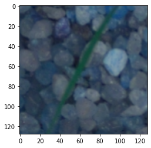

```python
i = 4099
img1 = trainImg[i]
label = trainLabel['Label'].values[i]
print(f'Image name:{label}')
plt.imshow(img1)
```

```
Image name:Maize
```

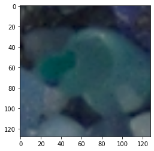

```python
i = 3614
img1 = trainImg[i]
label = trainLabel['Label'].values[i]
print(f'Image name:{label}')
plt.imshow(img1)
```

```
Image name:Scentless Mayweed
```

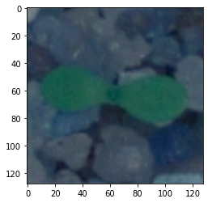

```python
i = 2713
img1 = trainImg[i]
label = trainLabel['Label'].values[i]
print(f'Image name:{label}')
plt.imshow(img1)
```

```
Image name:Shepherds Purse
```

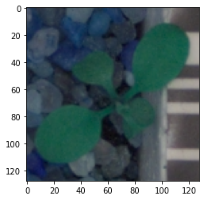

```python
i = 973
img1 = trainImg[i]
label = trainLabel['Label'].values[i]
print(f'Image name:{label}')
plt.imshow(img1)
```

```
Image name:Small-flowered Cranesbill
```

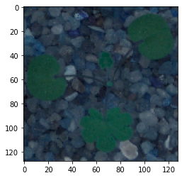

```python
i = 1
img1 = trainImg[i]
label = trainLabel['Label'].values[i]
print(f'Image name:{label}')
plt.imshow(img1)
```

```
Image name:Sugar beet
```

[figure not shown]

```python
i = 3229
img1 = trainImg[i]
label = trainLabel['Label'].values[i]
print(f'Image name:{label}')
plt.imshow(img1)
```

```python
CATEGORIES = ["Black-grass","Charlock","Common Chickweed","Common wheat","Fat Hen","Loose Silky-bent","Maize","Scentless Mayweed","Shepherds Purse","Small-flowered Cranesbill","Sugar beet"]
```

```python
def find_mean_img(full_mat, title):
    # calculate the average
    mean_img = np.mean(full_mat, axis = 0)
    # reshape it back to a matrix
    mean_img = mean_img.reshape((150,150))
    plt.imshow(mean_img, vmin=0, vmax=255, cmap='Greys_r')
    plt.title(f'Average {title}')
    plt.axis('off')
    plt.show()
    return mean_img


Blackgrass=[]
Charlock=[]
Cleavers=[]
CommonChickweed=[]
Commonwheat=[]
FatHen=[]
LooseSilkybent=[]
Maize=[]
ScentlessMayweed=[]
ShepherdsPurse=[]
SmallfloweredCranesbill=[]
Sugarbeet=[]

for cat in CATEGORIES:
                img_array = cv2.img_array(Img),cv2.IMREAD_GRAYSCALE # Converting image to greyscale to reduce the complexity and computation
                new_array = cv2.resize(img_array,(IMG_SIZE,IMG_SIZE))
                if cat==CATEGORIES[0]:
                      Blackgrass.append([new_array])
                if cat==CATEGORIES[1]:
                      Charlock.append([new_array])
                if cat==CATEGORIES[2]:
                      Cleavers.append([new_array])
                if cat==CATEGORIES[3]:
                      CommonChickweed.append([new_array])
                if cat==CATEGORIES[4]:
                      Commonwheat.append([new_array])
                if cat==CATEGORIES[5]:
                      FatHen.append([new_array])
                if cat==CATEGORIES[6]:
                      LooseSilkybent.append([new_array])
                if cat==CATEGORIES[7]:
                      Maize.append([new_array])
                if cat==CATEGORIES[8]:
                      ScentlessMayweed.append([new_array])
                if cat==CATEGORIES[9]:
                      ShepherdsPurse.append([new_array])
                if cat==CATEGORIES[10]:
                      SmallfloweredCranesbill.append([new_array])
                if cat==CATEGORIES[11]:
                      Sugarbeet.append([new_array])

Blackgrass_mean = find_mean_img(np.array(Blackgrass_data), 'Black-grass')
Charlock_mean = find_mean_img(np.array(Charlock_data), 'Charlock')
Cleavers_mean = find_mean_img(np.array(Cleavers_data), 'Cleavers')
Commonwheat_mean = find_mean_img(np.array(Commonwheat_data), 'Common wheat')
CommonChickweed_mean = find_mean_img(np.array(CommonChickweed_data), 'Common Chickweed')
FatHen_mean = find_mean_img(np.array(FatHen_data), 'Fat Hen')
LooseSilkybent_mean = find_mean_img(np.array(LooseSilkybent_data), 'Loose Silky-bent')
Maizemean = find_mean_img(np.array(Maize_data), 'Maize')
ScentlessMayweed_mean = find_mean_img(np.array(ScentlessMayweed_data), 'ScentlessMayweed')
ShepherdsPurse_mean = find_mean_img(np.array(ShepherdsPurse_data), 'ShepherdsPurse')
SmallfloweredCranesbill_mean = find_mean_img(np.array(SmallfloweredCranesbill_data), 'Small-floweredCranesbill')
Sugarbeet_mean = find_mean_img(np.array(Sugarbeet_data), 'Sugarbeet')
```

[output not shown]

### Data Pre - Processing

```python
trainImg = trainImg.astype('float32')
trainImg /= 255
# Check the nomalized data
print(f'Shape of the Train array:{trainImg.shape}')
print(f'Minimum value in the Train Array:{trainImg.min()}')
print(f'Maximum value in the Train Array:{trainImg.max()}')
```

```
Shape of the Train array:(4750, 128, 128, 3)
Minimum value in the Train Array:0.0
Maximum value in the Train Array:1.0
```

```python
#plit train and test set
X_train, X_test, y_train, y_test = train_test_split(trainImg, trainLabel, test_size=0.3, random_state=25)
X_train.shape, X_test.shape
```

```
((3325, 128, 128, 3), (1425, 128, 128, 3))
```

```python
#Split validation from test set
X_test, X_validation, y_test, y_validation = train_test_split(X_test, y_test, test_size=0.4, random_state=25)
X_test.shape, X_validation.shape
```

```
((855, 128, 128, 3), (570, 128, 128, 3))
```

### One Hot encoding to target values

```python
from sklearn.preprocessing import LabelBinarizer
encoder = LabelBinarizer()
y_train = encoder.fit_transform(y_train)
y_test = encoder.fit_transform(y_test)
y_validation = encoder.fit_transform(y_validation)
```

```python
# Display target variable
y_train[0]
```

```
array([0, 0, 0, 0, 0, 1, 0, 0, 0, 0, 0, 0])
```

### Gaussian Blurring

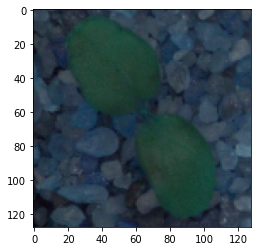

```python
# Preview the image before Gaussian Blur
plt.imshow(X_train[1], cmap='gray')
```

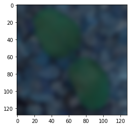

```python
plt.imshow(cv2.GaussianBlur(X_train[1], (15,15), 0))
```

```python
# Now we apply the gaussian blur to each 128x128 pixels array (image) to reduce the noise in the image
for idx, img in enumerate(X_train):
  X_train[idx] = cv2.GaussianBlur(img, (5, 5), 0)
```

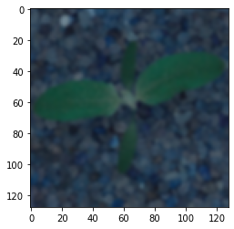

```python
# Preview the image after Gaussian Blur
plt.imshow(X_train[0], cmap='gray')
```

```python
# Gaussian Blue to Test and Validation sets
for idx, img in enumerate(X_test):
      X_test[idx] = cv2.GaussianBlur(img, (5, 5), 0)

for idx, img in enumerate(X_validation):
      X_validation[idx] = cv2.GaussianBlur(img, (5, 5), 0)
```

### Model Building

#### CNN with dropout

```python
def create_model(input_shape, num_classes):
  # Initialize CNN Classified
  model = Sequential()

  # Add convolution layer with 32 filters and 3 kernels
  model.add(Conv2D(32, (3,3), input_shape=input_shape, padding='same', activation=tf.nn.relu))
  model.add(MaxPooling2D(pool_size=(2,2)))
  model.add(Dropout(rate=0.25))

  # Add convolution layer with 32 filters and 3 kernels
  model.add(Conv2D(filters=32, kernel_size=3, padding='same', activation=tf.nn.relu))
  model.add(Conv2D(filters=64, kernel_size=3, padding='same', activation=tf.nn.relu))
  model.add(MaxPooling2D(pool_size=(2,2)))
  model.add(Dropout(rate=0.25))

  # Add convolution layer with 32 filters and 3 kernels
  model.add(Conv2D(filters=32, kernel_size=3, padding='same', activation=tf.nn.relu))
  model.add(MaxPooling2D(pool_size=(2,2)))
  model.add(Dropout(rate=0.25))

  # Flatten the 2D array to 1D array
  model.add(Flatten())

  # Create fully connected layers with 512 units
  model.add(Dense(512, activation=tf.nn.relu))
  model.add(Dropout(0.5))


  # Adding a fully connected layer with 128 neurons
  model.add(Dense(units = 128, activation = tf.nn.relu))
  model.add(Dropout(0.5))

  # The final output layer with 12 neurons to predict the categorical classifcation
  model.add(Dense(units = num_classes, activation = tf.nn.softmax))
  return model
```

```python
class myCallback(tf.keras.callbacks.Callback):
  def on_epoch_end(self, epoch, logs={}):
    if(logs.get('accuracy')>0.95):
      print("\nReached 95% accuracy so cancelling training!")
      self.model.stop_training = True

callbacks = myCallback()

es = EarlyStopping(monitor='val_accuracy', mode='min', verbose=1, patience=10)
```

```python
input_shape = X_train.shape[1:] # Input shape of X_train
num_classes = y_train.shape[1] # Target column size

model = create_model(input_shape, num_classes)
optimizer = tf.keras.optimizers.Adam(learning_rate=0.001) # Optimizer
# optimizer = tf.keras.optimizers.SGD(lr=1 * 1e-1, momentum=0.9, nesterov=True)

model.compile(optimizer=optimizer,
              loss='categorical_crossentropy',
              metrics=['accuracy'])

model.summary()
```

```
Model: "sequential_4"
_________________________________________________________________
Layer (type)                 Output Shape              Param #
=================================================================
conv2d_10 (Conv2D)           (None, 128, 128, 32)      896
_________________________________________________________________
max_pooling2d_10 (MaxPooling (None, 64, 64, 32)        0
_________________________________________________________________
dropout_12 (Dropout)         (None, 64, 64, 32)        0
_________________________________________________________________
conv2d_11 (Conv2D)           (None, 64, 64, 32)        9248
_________________________________________________________________
conv2d_12 (Conv2D)           (None, 64, 64, 64)        18496
_________________________________________________________________
max_pooling2d_11 (MaxPooling (None, 32, 32, 64)        0
_________________________________________________________________
dropout_13 (Dropout)         (None, 32, 32, 64)        0
_________________________________________________________________
conv2d_13 (Conv2D)           (None, 32, 32, 32)        18464
_________________________________________________________________
max_pooling2d_12 (MaxPooling (None, 16, 16, 32)        0
_________________________________________________________________
dropout_14 (Dropout)         (None, 16, 16, 32)        0
_________________________________________________________________
flatten_4 (Flatten)          (None, 8192)              0
_________________________________________________________________
dense_10 (Dense)             (None, 512)               4194816
_________________________________________________________________
dropout_15 (Dropout)         (None, 512)               0
_________________________________________________________________
dense_11 (Dense)             (None, 128)               65664
_________________________________________________________________
dropout_16 (Dropout)         (None, 128)               0
_________________________________________________________________
dense_12 (Dense)             (None, 12)                1548
=================================================================
Total params: 4,309,132
Trainable params: 4,309,132
Non-trainable params: 0
_________________________________________________________________
```

```python
history = model.fit(X_train, y_train, validation_data=(X_validation, y_validation), epochs=30, batch_size=100, callbacks=[callbacks])
```

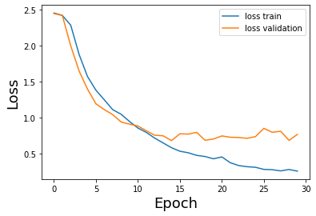

```python
plt.plot(history.history['loss'])
plt.plot(history.history['val_loss'])
plt.xlabel('Epoch', fontsize=18)
plt.ylabel(r'Loss', fontsize=18)
plt.legend(('loss train','loss validation'), loc=0)
```

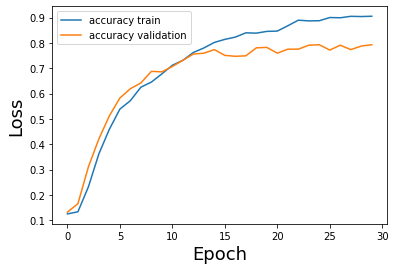

```python
# Print accuracy
plt.plot(history.history['accuracy'])
plt.plot(history.history['val_accuracy'])
plt.xlabel('Epoch', fontsize=18)
plt.ylabel(r'Loss', fontsize=18)
plt.legend(('accuracy train','accuracy validation'), loc=0)
```

Model Evaluation

```python
loss, accuracy = model.evaluate(X_test, y_test)
print('Test loss: {:.2f} \n Test accuracy: {:.2f}'.format(loss, accuracy))

loss, accuracy = model.evaluate(X_train, y_train)
print('Train loss: {:.2f} \n Train accuracy: {:.2f}'.format(loss, accuracy))
```

```
Test loss: 0.78
 Test accuracy: 0.80
Train loss: 0.09
 Train accuracy: 0.98
```

Model retraining

```python
model1 = create_model(input_shape, num_classes)
optimizer = tf.keras.optimizers.Adam(learning_rate=0.001) # Optimizer

model1.compile(optimizer=optimizer,
              loss='categorical_crossentropy',
              metrics=['accuracy'])

model1.summary()
```

```
Model: "sequential_5"
_________________________________________________________________
Layer (type)                 Output Shape              Param #
=================================================================
conv2d_14 (Conv2D)           (None, 128, 128, 32)      896
_________________________________________________________________
max_pooling2d_13 (MaxPooling (None, 64, 64, 32)        0
_________________________________________________________________
dropout_17 (Dropout)         (None, 64, 64, 32)        0
_________________________________________________________________
conv2d_15 (Conv2D)           (None, 64, 64, 32)        9248
_________________________________________________________________
conv2d_16 (Conv2D)           (None, 64, 64, 64)        18496
_________________________________________________________________
max_pooling2d_14 (MaxPooling (None, 32, 32, 64)        0
_________________________________________________________________
dropout_18 (Dropout)         (None, 32, 32, 64)        0
_________________________________________________________________
conv2d_17 (Conv2D)           (None, 32, 32, 32)        18464
_________________________________________________________________
max_pooling2d_15 (MaxPooling (None, 16, 16, 32)        0
_________________________________________________________________
dropout_19 (Dropout)         (None, 16, 16, 32)        0
_________________________________________________________________
flatten_5 (Flatten)          (None, 8192)              0
_________________________________________________________________
dense_13 (Dense)             (None, 512)               4194816
_________________________________________________________________
dropout_20 (Dropout)         (None, 512)               0
_________________________________________________________________
dense_14 (Dense)             (None, 128)               65664
_________________________________________________________________
dropout_21 (Dropout)         (None, 128)               0
_________________________________________________________________
dense_15 (Dense)             (None, 12)                1548
=================================================================
Total params: 4,309,132
Trainable params: 4,309,132
Non-trainable params: 0
_________________________________________________________________
```

```python
history = model1.fit(X_train, y_train, validation_data=(X_validation, y_validation), epochs=18, callbacks=[callbacks])
```

```python
loss, accuracy = model1.evaluate(X_test, y_test)
print('Test loss: {:.2f} \n Test accuracy: {:.2f}'.format(loss, accuracy))

loss, accuracy = model1.evaluate(X_train, y_train)
print('Train loss: {:.2f} \n Train accuracy: {:.2f}'.format(loss, accuracy))
```

```
Test loss: 0.84
 Test accuracy: 0.71
Train loss: 0.34
 Train accuracy: 0.88
```

Visualize Prediction

```
Predicted label: Loose Silky-bent
```

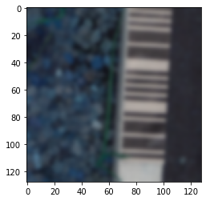

```python
y_pred = encoder.inverse_transform(y_pred)

index = 5
plt.imshow(X_test[index], cmap='gray')
print("Predicted label:", y_pred[index])
```

```
Predicted label: Cleavers
```

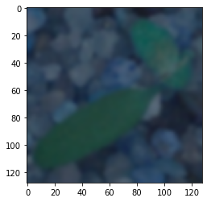

```python
index = 25
plt.imshow(X_test[index], cmap='gray')
print("Predicted label:", y_pred[index])
```

```
Predicted label: Sugar beet
```

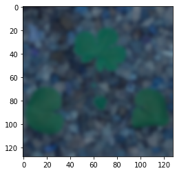

```python
index = 36
plt.imshow(X_test[index], cmap='gray')
print("Predicted label:", y_pred[index])
```

```
Predicted label: Loose Silky-bent
```

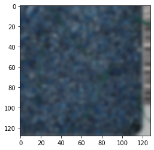

```python
index = 39
plt.imshow(X_test[index], cmap='gray')
print("Predicted label:", y_pred[index])
```

```
Predicted label: Cleavers
```

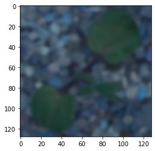

```python
index = 60
plt.imshow(X_test[index], cmap='gray')
print("Predicted label:", y_pred[index])
```

```
Predicted label: Small-flowered Cranesbill
```

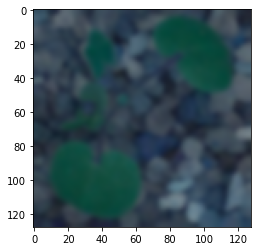

```python
index = 400
plt.imshow(X_test[index], cmap='gray')
print("Predicted label:", y_pred[index])
```

```
Predicted label: Fat Hen
```

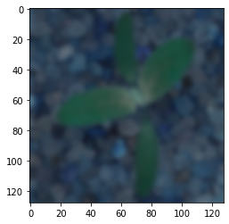

```python
index = 500
plt.imshow(X_test[index], cmap='gray')
print("Predicted label:", y_pred[index])
```

```
Predicted label: Scentless Mayweed
```

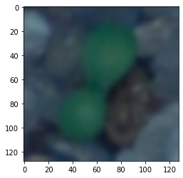

```python
index = 750
plt.imshow(X_test[index], cmap='gray')
print("Predicted label:", y_pred[index])
```

### **Conclusion**

There is still scope for improvement in the test accuracy of the CNN model chosen here. Different models can be built and hyperparamter tuning can be performed to obtain a better classifier.